# JAX

Lecture 25

## JAX

> JAX is NumPy on the CPU, GPU, and TPU, with great automatic differentiation for high-performance machine learning research.
> - JAX provides a NumPy-inspired interface for convenience (`jax.numpy`), can often be used as drop-in replacement
> - All JAX operations are implemented in terms of operations in XLA (Accelerated Linear Algebra compiler)
> - Supports sequential execution or JIT compilation
> - Updated autograd which can be used with native Python and NumPy functions

## JAX & NumPy

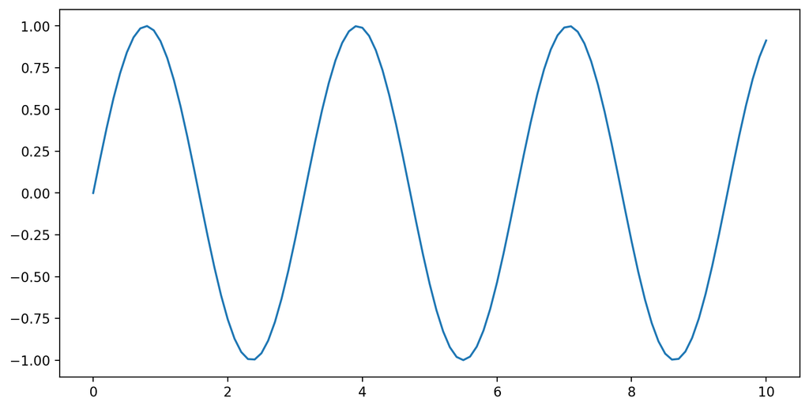

```python
import numpy as np

x_np = np.linspace(0, 10, 101)
y_np = 2 * np.sin(x_np) * np.cos(x_np)
plt.plot(x_np, y_np)
```

```python
type(x_np)
```

```
numpy.ndarray
```

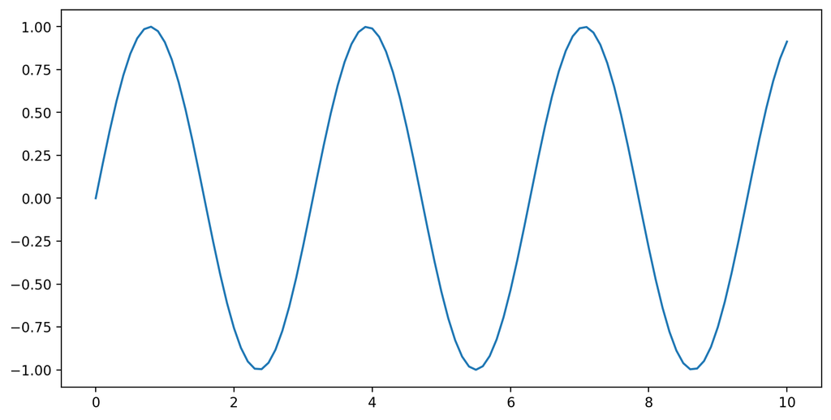

```python
import jax.numpy as jnp

x_jnp = jnp.linspace(0, 10, 101)
y_jnp = 2 * jnp.sin(x_jnp) * jnp.cos(x_jnp)
plt.plot(x_jnp, y_jnp)
```

```python
type(x_jnp)
```

```
jaxlib._jax.ArrayImpl
```

```python
x_np
```

```
array([ 0. ,  0.1,  0.2,  0.3,  0.4,  0.5,  0.6,  0.7,
        0.8,  0.9,  1. ,  1.1,  1.2,  1.3,  1.4,  1.5,
        1.6,  1.7,  1.8,  1.9,  2. ,  2.1,  2.2,  2.3,
        2.4,  2.5,  2.6,  2.7,  2.8,  2.9,  3. ,  3.1,
        3.2,  3.3,  3.4,  3.5,  3.6,  3.7,  3.8,  3.9,
        4. ,  4.1,  4.2,  4.3,  4.4,  4.5,  4.6,  4.7,
        4.8,  4.9,  5. ,  5.1,  5.2,  5.3,  5.4,  5.5,
        5.6,  5.7,  5.8,  5.9,  6. ,  6.1,  6.2,  6.3,
        6.4,  6.5,  6.6,  6.7,  6.8,  6.9,  7. ,  7.1,
        7.2,  7.3,  7.4,  7.5,  7.6,  7.7,  7.8,  7.9,
        8. ,  8.1,  8.2,  8.3,  8.4,  8.5,  8.6,  8.7,
        8.8,  8.9,  9. ,  9.1,  9.2,  9.3,  9.4,  9.5,
        9.6,  9.7,  9.8,  9.9, 10. ])
```

```python
x_np.dtype
```

```
dtype('float64')
```

```python
x_jnp
```

```
Array([ 0. ,  0.1,  0.2,  0.3,  0.4,  0.5,  0.6,  0.7,
        0.8,  0.9,  1. ,  1.1,  1.2,  1.3,  1.4,  1.5,
        1.6,  1.7,  1.8,  1.9,  2. ,  2.1,  2.2,  2.3,
        2.4,  2.5,  2.6,  2.7,  2.8,  2.9,  3. ,  3.1,
        3.2,  3.3,  3.4,  3.5,  3.6,  3.7,  3.8,  3.9,
        4. ,  4.1,  4.2,  4.3,  4.4,  4.5,  4.6,  4.7,
        4.8,  4.9,  5. ,  5.1,  5.2,  5.3,  5.4,  5.5,
        5.6,  5.7,  5.8,  5.9,  6. ,  6.1,  6.2,  6.3,
        6.4,  6.5,  6.6,  6.7,  6.8,  6.9,  7. ,  7.1,
        7.2,  7.3,  7.4,  7.5,  7.6,  7.7,  7.8,  7.9,
        8. ,  8.1,  8.2,  8.3,  8.4,  8.5,  8.6,  8.7,
        8.8,  8.9,  9. ,  9.1,  9.2,  9.3,  9.4,  9.5,
        9.6,  9.7,  9.8,  9.9, 10. ], dtype=float32)
```

```python
x_jnp.dtype
```

```
dtype('float32')
```

## Compatibility

```python
y_mix = 2 * np.sin(x_jnp) * jnp.cos(x_np); y_mix
```

```
Array([ 0.     ,  0.19867,  0.38942,  0.56464,  0.71736,
        0.84147,  0.93204,  0.98545,  0.99957,  0.97385,
        0.9093 ,  0.8085 ,  0.67546,  0.5155 ,  0.33499,
        0.14112, -0.05837, -0.25554, -0.44252, -0.61186,
       -0.7568 , -0.87158, -0.9516 , -0.99369, -0.99616,
       -0.95892, -0.88345, -0.77276, -0.63127, -0.4646 ,
       -0.27942, -0.08309,  0.11655,  0.31154,  0.49411,
        0.65699,  0.79367,  0.89871,  0.96792,  0.99854,
        0.98936,  0.94073,  0.8546 ,  0.7344 ,  0.58492,
        0.41212,  0.22289,  0.02478, -0.17433, -0.36648,
       -0.54402, -0.69987, -0.82783, -0.92278, -0.98094,
       -0.99999, -0.97918, -0.91933, -0.82283, -0.69353,
       -0.53657, -0.35823, -0.1656 ,  0.03362,  0.23151,
        0.42017,  0.59207,  0.74038,  0.85916,  0.9437 ,
        0.99061,  0.99803,  0.96566,  0.89479,  0.78825,
        0.65029,  0.4864 ,  0.30312,  0.10775, -0.09191,
       -0.2879 , -0.47242, -0.63811, -0.77835, -0.88757,
       -0.9614 , -0.9969 , -0.99266, -0.94885, -0.8672 ,
       -0.75099, -0.60483, -0.43457, -0.24698, -0.04954,
        0.14988,  0.34331,  0.52307,  0.68196,  0.81367,
        0.91295], dtype=float32)
```

```python
type(y_mix)
```

```
jaxlib._jax.ArrayImpl
```

# Aside - PRNG

## JAX vs NumPy

Pseudo random number generation in JAX is a bit different than with NumPy - the latter depends on a global state that is updated each time a random function is called.

NumPy’s PRNG guarantees something called sequential equivalence which amounts to sampling N numbers sequentially is the same as sampling N numbers at once (e.g. a vector of length N).

```python
np.random.seed(0)
print("individually:", np.stack([np.random.uniform() for i in range(5)]))
```

```
individually: [0.54881 0.71519 0.60276 0.54488 0.42365]
```

```python
np.random.seed(0)
print("all at once: ", np.random.uniform(size=5))
```

```
all at once:  [0.54881 0.71519 0.60276 0.54488 0.42365]
```

## Parallelization & Sequential equivalence

Sequantial equivalence can be problematic in light of parallelization, consider the following code:

```python
np.random.seed(0)

def bar():
  return np.random.uniform()
def baz():
  return np.random.uniform()

def foo():
  return bar() + 2 * baz()
```

How do we guarantee that we get consistent results if we don’t know the order that `bar()` and `baz()` will run?

## PRNG keys

JAX makes use of ’random keys` which are just a fancier version of random seeds - all of JAX’s random functions require that a key be passed in.

```python
key = jax.random.PRNGKey(1234); key
```

```
Array([   0, 1234], dtype=uint32)
```

```python
jax.random.normal(key)
```

```
Array(1.1031, dtype=float32)
```

```python
jax.random.normal(key)
```

```
Array(1.1031, dtype=float32)
```

```python
jax.random.normal(key, shape=(3,))
```

```
Array([ 1.1031 ,  0.86306, -0.33868], dtype=float32)
```

Note that JAX does not provide a sequential equivalence guarantee - this is so that it can support vectorization for the generation of PRN.

## Splitting keys

Since a key is essentially a seed we do not want to reuse them (unless we want an identical output). Therefore to generate multiple different PRN we can split a key to deterministically generate two (or more) new keys.

```python
new_key1, sub_key1 = jax.random.split(key)
print(f"key    : {key}")
print(f"new_key1: {new_key1}")
print(f"sub_key1: {sub_key1}")
```

```
key    : [   0 1234]
new_key1: [1264997412 2518116175]
sub_key1: [2877103387 1697627890]
```

```python
new_key2, sub_key2 = jax.random.split(key)
print(f"key    : {key}")
print(f"new_key2: {new_key2}")
print(f"sub_key2: {sub_key2}")
```

```
key    : [   0 1234]
new_key2: [1264997412 2518116175]
sub_key2: [2877103387 1697627890]
```

```python
new_key3, *sub_keys3 = jax.random.split(key, num=3)
sub_keys3
```

```
[Array([2877103387, 1697627890], dtype=uint32),
 Array([2113592192,  603280156], dtype=uint32)]
```

# JAX performance & jit

## JAX performance

```python
key = jax.random.PRNGKey(1234)
x_jnp = jax.random.normal(key, (1000,1000))
x_np = np.array(x_jnp)
```

```python
type(x_np)
```

```
numpy.ndarray
```

```python
x_np.shape
```

```
(1000, 1000)
```

```python
type(x_jnp)
```

```
jaxlib._jax.ArrayImpl
```

```python
x_jnp.shape
```

```
(1000, 1000)
```

```python
%timeit y = x_np @ x_np
```

```
903 μs ± 209 μs per loop (mean ± std. dev. of 7 runs, 1,000 loops each)
```

```python
%timeit y = x_jnp @ x_jnp
```

```
744 μs ± 11.6 μs per loop (mean ± std. dev. of 7 runs, 1,000 loops each)
```

```python
%timeit y = (x_jnp @ x_jnp).block_until_ready()
```

```
752 μs ± 3.38 μs per loop (mean ± std. dev. of 7 runs, 1,000 loops each)
```

```python
%timeit y = 3*x_np + x_np
```

```
180 μs ± 73.3 ns per loop (mean ± std. dev. of 7 runs, 10,000 loops each)
```

```python
%timeit y = 3*x_jnp + x_jnp
```

```
391 μs ± 19.9 μs per loop (mean ± std. dev. of 7 runs, 1,000 loops each)
```

```python
%timeit y = (3*x_jnp + x_jnp).block_until_ready()
```

```
389 μs ± 1.46 μs per loop (mean ± std. dev. of 7 runs, 1,000 loops each)
```

## jit

```python
def SELU_np(x, α=1.67, λ=1.05):
  "Scaled Exponential Linear Unit"
  return λ * np.where(x > 0, x, α * np.exp(x) - α)
```

```python
def SELU_jnp(x, α=1.67, λ=1.05):
  "Scaled Exponential Linear Unit"
  return λ * jnp.where(x > 0, x, α * jnp.exp(x) - α)
```

```python
SELU_np_jit = jax.jit(SELU_np)
```

```python
SELU_jnp_jit = jax.jit(SELU_jnp)
```

```python
x = np.arange(1e6)
%timeit y = SELU_np(x)
```

```
3.77 ms ± 4.88 μs per loop (mean ± std. dev. of 7 runs, 100 loops each)
```

```python
%timeit y = SELU_np_jit(x).block_until_ready()
```

```
---------------------------------------------------------------------------
TracerArrayConversionError                Traceback (most recent call last)
Cell In[38], line 1
----> 1 get_ipython().run_line_magic('timeit', 'y = SELU_np_jit(x).block_until_ready()')

File ~/.conda/envs/qmd-slides/lib/python3.11/site-packages/IPython/core/interactiveshell.py:2511, in InteractiveShell.run_line_magic(self, magic_name, line, _stack_depth)
   2509     kwargs['local_ns'] = self.get_local_scope(stack_depth)
   2510 with self.builtin_trap:
-> 2511     result = fn(*args, **kwargs)
   2513 # The code below prevents the output from being displayed
   2514 # when using magics with decorator @output_can_be_silenced
   2515 # when the last Python token in the expression is a ';'.
   2516 if getattr(fn, magic.MAGIC_OUTPUT_CAN_BE_SILENCED, False):

File ~/.conda/envs/qmd-slides/lib/python3.11/site-packages/IPython/core/magics/execution.py:1222, in ExecutionMagics.timeit(self, line, cell, local_ns)
   1220 for index in range(0, 10):
   1221     number = 10 ** index
-> 1222     time_number = timer.timeit(number)
   1223     if time_number >= 0.2:
   1224         break

File ~/.conda/envs/qmd-slides/lib/python3.11/site-packages/IPython/core/magics/execution.py:184, in Timer.timeit(self, number)
    182 gc.disable()
    183 try:
--> 184     timing = self.inner(it, self.timer)
    185 finally:
    186     if gcold:

File <magic-timeit>:1, in inner(_it, _timer)

    [... skipping hidden 5 frame]

Cell In[33], line 3, in SELU_np(x, α, λ)
      1 def SELU_np(x, α=1.67, λ=1.05):
      2   "Scaled Exponential Linear Unit"
----> 3   return λ * np.where(x > 0, x, α * np.exp(x) - α)

File ~/.conda/envs/qmd-slides/lib/python3.11/site-packages/jax/_src/core.py:931, in Tracer.__array__(self, *args, **kw)
    930 def __array__(self, *args, **kw):
--> 931   raise TracerArrayConversionError(self)

TracerArrayConversionError: The numpy.ndarray conversion method __array__() was called on traced array with shape float32[1000000]
The error occurred while tracing the function SELU_np at /tmp/ipykernel_1416923/762427251.py:1 for jit. This concrete value was not available in Python because it depends on the value of the argument x.
See https://docs.jax.dev/en/latest/errors.html#jax.errors.TracerArrayConversionError
```

```python
x = jnp.arange(1e6)
%timeit y = SELU_jnp(x).block_until_ready()
```

```
1.49 ms ± 8.25 μs per loop (mean ± std. dev. of 7 runs, 1,000 loops each)
```

```python
%timeit y = SELU_jnp_jit(x).block_until_ready()
```

```
105 μs ± 2.15 μs per loop (mean ± std. dev. of 7 runs, 10,000 loops each)
```

## jit limitations

When it works the jit tool is fantastic, but it does have a number of limitations,

- Must use [pure functions](https://jax.readthedocs.io/en/latest/notebooks/Common_Gotchas_in_JAX.html#pure-functions) (no side effects)
- Must primarily use JAX functions
  - e.g. use `jnp.minimum()` not `np.minimum()` or `min()`
- Must generally avoid conditionals / control flow
- Issues around concrete values when tracing (static values)
- Check performance - there are not always gains + there is the initial cost of compilation

# autograd

## Basics

Like with torch, the `grad()` function takes a numerical function returning a scalar and returns a function for calculating the gradient of that function.

```python
def f(x):
  return x**2
```

```python
f(3.)
```

```
9.0
```

```python
jax.grad(f)(3.)
```

```
Array(6., dtype=float32, weak_type=True)
```

```python
jax.grad(jax.grad(f))(3.)
```

```
Array(2., dtype=float32, weak_type=True)
```

```python
def g(x):
  return jnp.exp(-x)
```

```python
g(1.)
```

```
Array(0.36788, dtype=float32, weak_type=True)
```

```python
jax.grad(g)(1.)
```

```
Array(-0.36788, dtype=float32, weak_type=True)
```

```python
jax.grad(jax.grad(g))(1.)
```

```
Array(0.36788, dtype=float32, weak_type=True)
```

```python
def h(x):
  return jnp.maximum(0,x)
```

```python
h(-2.)
```

```
Array(0., dtype=float32, weak_type=True)
```

```python
h(2.)
```

```
Array(2., dtype=float32, weak_type=True)
```

```python
jax.grad(h)(-2.)
```

```
Array(0., dtype=float32, weak_type=True)
```

```python
jax.grad(h)(2.)
```

```
Array(1., dtype=float32, weak_type=True)
```

## Aside - `vmap()`

I would like to plot `h()` and `jax.grad(h)()` - lets see what happens,

```python
x = jnp.linspace(-3,3,101)
y = h(x)
y_grad = jax.grad(h)(x)
```

```
---------------------------------------------------------------------------
TypeError                                 Traceback (most recent call last)
Cell In[54], line 3
      1 x = jnp.linspace(-3,3,101)
      2 y = h(x)
----> 3 y_grad = jax.grad(h)(x)

    [... skipping hidden 4 frame]

File ~/.conda/envs/qmd-slides/lib/python3.11/site-packages/jax/_src/api.py:564, in _check_scalar(x)
    562 if isinstance(aval, ShapedArray):
    563   if aval.shape != ():
--> 564     raise TypeError(msg(f"had shape: {aval.shape}"))
    565 else:
    566   raise TypeError(msg(f"had abstract value {aval}"))

TypeError: Gradient only defined for scalar-output functions. Output had shape: (101,).
```

As mentiond on the previous slide - in order to calculate the gradient we need to apply it to a scalar valued function. We can transform our scalar function into a vectorized function using `vmap()`.

```python
y_grad = jax.vmap(
  jax.grad(h)
)(x)
```

`vmap()` is significantly more powerful than just this as it allows for mapping over multiple input and output axes

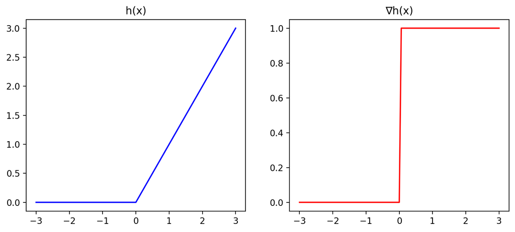

## Regession example

```python
d = pd.read_csv("https://sta663-sp23.github.io/slides/data/ridge.csv");d
```

```
            y        x1        x2        x3        x4 x5
0   -0.151710  0.353658  1.633932  0.553257  1.415731  A
1    3.579895  1.311354  1.457500  0.072879  0.330330  B
2    0.768329 -0.744034  0.710362 -0.246941  0.008825  B
3    7.788646  0.806624 -0.228695  0.408348 -2.481624  B
4    1.394327  0.837430 -1.091535 -0.860979 -0.810492  A
..        ...       ...       ...       ...       ... ..
495 -0.204932 -0.385814 -0.130371 -0.046242  0.004914  A
496  0.541988  0.845885  0.045291  0.171596  0.332869  A
497 -1.402627 -1.071672 -1.716487 -0.319496 -1.163740  C
498 -0.043645  1.744800 -0.010161  0.422594  0.772606  A
499 -1.550276  0.910775 -1.675396  1.921238 -0.232189  B

[500 rows x 6 columns]
```

```python
X = jnp.array(
  pd.get_dummies(
    d.drop("y", axis=1)
  ).to_numpy(dtype = np.float32)
)
X.shape
```

```
(500, 8)
```

```python
y = jnp.array(
  d.y.to_numpy(dtype = np.float32)
)
y.shape
```

```
(500,)
```

## Model & loss functions

```python
def model(b, X=X):
  return X @ b

def reg_loss(b, λ=0., X=X, y=y, model=model):
  return jnp.mean((y - model(b,X).squeeze())**2)

def ridge_loss(b, λ=0., X=X, y=y, model=model):
  return jnp.mean((y - model(b,X).squeeze())**2) + λ * jnp.sum(b**2)

def lasso_loss(b, λ=0., X=X, y=y, model=model):
  return jnp.mean((y - model(b,X).squeeze())**2) + λ * jnp.sum(jnp.abs(b))
```

`grad()` of a multiargument function will take the gradient with respect to the first argument.

```python
grad_reg_loss = jax.grad(reg_loss)
grad_ridge_loss = jax.grad(ridge_loss)
grad_lasso_loss = jax.grad(lasso_loss)
```

```python
key = jax.random.PRNGKey(1234)
b = jax.random.normal(key, (X.shape[1],1))
```

```python
grad_reg_loss(b)
```

```
Array([[-0.06252],
       [-1.60175],
       [-0.68263],
       [ 8.39182],
       [-0.58243],
       [ 0.25809],
       [ 0.94067],
       [-0.30483]], dtype=float32)
```

```python
grad_ridge_loss(b, λ = 1)
```

```
Array([[ 2.14368],
       [ 0.12437],
       [-1.36   ],
       [10.44632],
       [-2.72959],
       [ 0.91684],
       [ 2.45709],
       [-0.90598]], dtype=float32)
```

```python
grad_lasso_loss(b, λ = 1)
```

```
Array([[ 0.93748],
       [-0.60175],
       [-1.68263],
       [ 9.39182],
       [-1.58243],
       [ 1.25809],
       [ 1.94067],
       [-1.30483]], dtype=float32)
```

## sklearn

```python
from sklearn.linear_model import LinearRegression

lm = LinearRegression(fit_intercept=False).fit(X,y)
lm.coef_
```

```
array([ 0.99505,  2.00762,  0.00232, -3.00088,  0.49329,
        0.10193, -0.29413,  1.00856], dtype=float32)
```

## Fit implementation

```python
def fit(b, loss, λ=0., n=250, lr=0.01, X=X, y=y, model=model):
  val_grad = jax.value_and_grad(loss)

  losses = []
  for i in range(n):
    val, grad = val_grad(b, λ)
    losses.append(val.item())

    b -= lr * grad

  return (b, losses)
```

## Linear regression

```python
b = jax.random.normal(key, (X.shape[1],1))
b_hat, losses = fit(b, reg_loss)
```

```python
b_hat
```

```
Array([[ 1.00649],
       [ 2.00126],
       [-0.0075 ],
       [-2.97562],
       [ 0.08298],
       [ 0.12629],
       [-0.11814],
       [ 0.13199]], dtype=float32)
```

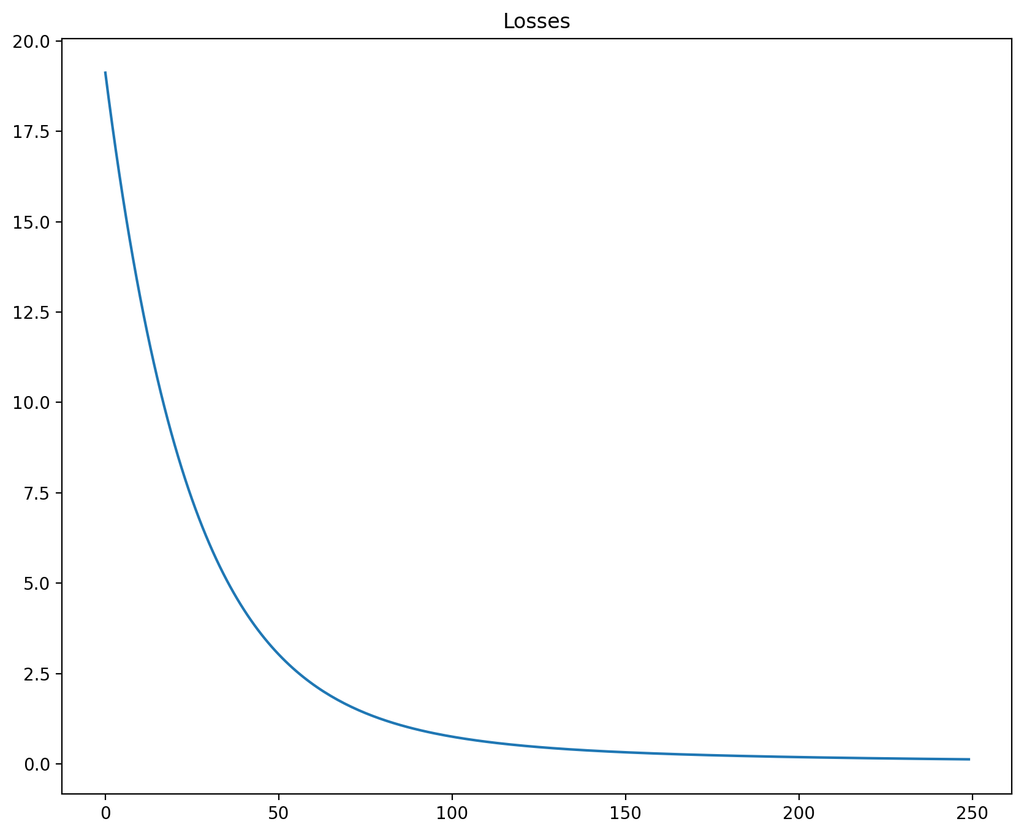

## Ridge regression

```python
b = jax.random.normal(key, (X.shape[1],1))
b_hat, losses = fit(b, ridge_loss, λ=0.1)
```

```python
b_hat
```

```
Array([[ 0.91965],
       [ 1.79126],
       [ 0.00259],
       [-2.71831],
       [ 0.11833],
       [ 0.07751],
       [-0.1421 ],
       [ 0.1544 ]], dtype=float32)
```

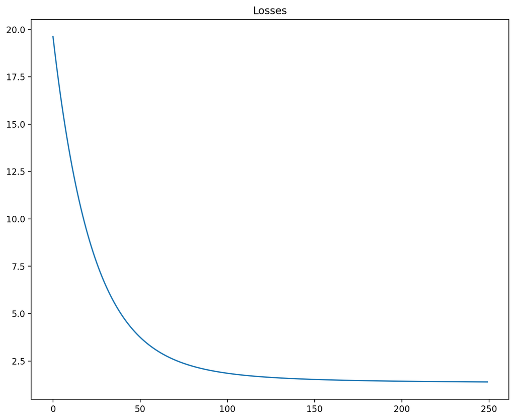

## Lasso regression

```python
b = jax.random.normal(key, (X.shape[1],1))
b_hat, losses = fit(b, lasso_loss, λ=0.1)
```

```python
b_hat
```

```
Array([[ 0.95792],
       [ 1.93753],
       [ 0.00038],
       [-2.92888],
       [ 0.10165],
       [-0.0003 ],
       [-0.07941],
       [ 0.06989]], dtype=float32)
```

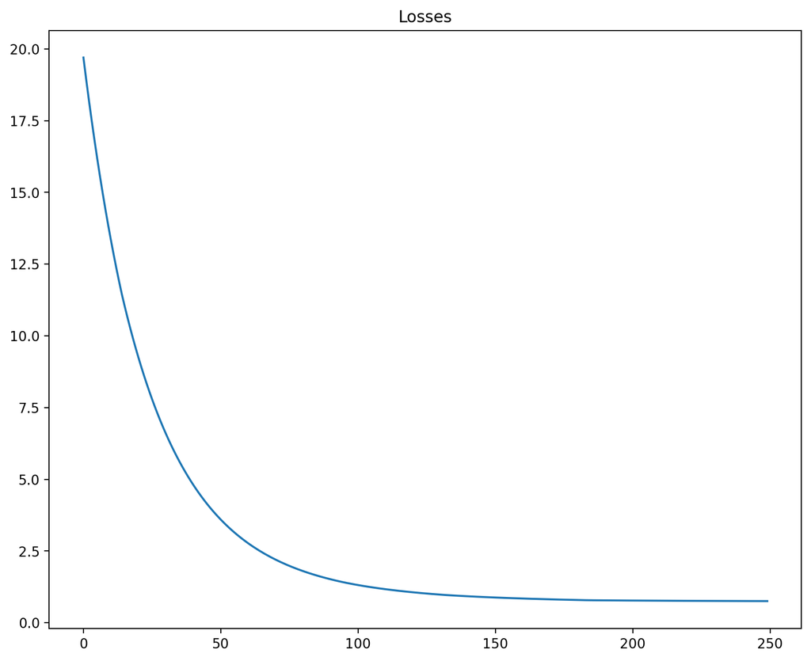

## Jitting fit?

```python
fit_jit = jax.jit(fit)
b_hat, losses = fit_jit(b, reg_loss, λ=0.1)
```

```
---------------------------------------------------------------------------
TypeError                                 Traceback (most recent call last)
Cell In[77], line 2
      1 fit_jit = jax.jit(fit)
----> 2 b_hat, losses = fit_jit(b, reg_loss, λ=0.1)

    [... skipping hidden 3 frame]

File ~/.conda/envs/qmd-slides/lib/python3.11/site-packages/jax/_src/pjit.py:649, in _infer_input_type(fun, dbg_fn, explicit_args)
    647   dbg = dbg_fn()
    648   arg_description = f"path {dbg.arg_names[i] if dbg.arg_names is not None else 'unknown'}"
--> 649   raise TypeError(
    650     f"Error interpreting argument to {fun} as an abstract array."
    651     f" The problematic value is of type {type(x)} and was passed to"
    652     f" the function at {arg_description}.\n"
    653     "This typically means that a jit-wrapped function was called with a non-array"
    654     " argument, and this argument was not marked as static using the"
    655     " static_argnums or static_argnames parameters of jax.jit."
    656   ) from None
    657 if config.mutable_array_checks.value:
    658   check_no_aliased_ref_args(dbg_fn, avals, explicit_args)

TypeError: Error interpreting argument to <function fit at 0x1552b14ba2a0> as an abstract array. The problematic value is of type <class 'function'> and was passed to the function at path loss.
This typically means that a jit-wrapped function was called with a non-array argument, and this argument was not marked as static using the static_argnums or static_argnames parameters of jax.jit.
```

```python
fit_jit = jax.jit(fit, static_argnames=["loss","λ","n","X","y","model"])
b_hat = fit_jit(b, reg_loss)
```

```
---------------------------------------------------------------------------
ConcretizationTypeError                   Traceback (most recent call last)
Cell In[78], line 2
      1 fit_jit = jax.jit(fit, static_argnames=["loss","λ","n","X","y","model"])
----> 2 b_hat = fit_jit(b, reg_loss)

    [... skipping hidden 5 frame]

Cell In[67], line 7, in fit(b, loss, λ, n, lr, X, y, model)
      5 for i in range(n):
      6   val, grad = val_grad(b, λ)
----> 7   losses.append(val.item())
      9   b -= lr * grad
     11 return (b, losses)

    [... skipping hidden 1 frame]

File ~/.conda/envs/qmd-slides/lib/python3.11/site-packages/jax/_src/numpy/array_methods.py:275, in _item(self, *args)
    273 def _item(self: Array, *args: int) -> bool | int | float | complex:
    274   """Copy an element of an array to a standard Python scalar and return it."""
--> 275   arr = core.concrete_or_error(np.asarray, self, context="This occurred in the item() method of jax.Array")
    276   if dtypes.issubdtype(self.dtype, dtypes.extended):
    277     raise TypeError(f"No Python scalar type for {arr.dtype=}")

File ~/.conda/envs/qmd-slides/lib/python3.11/site-packages/jax/_src/core.py:1905, in concrete_or_error(force, val, context)
   1903 maybe_concrete = val.to_concrete_value()
   1904 if maybe_concrete is None:
-> 1905   raise ConcretizationTypeError(val, context)
   1906 else:
   1907   return force(maybe_concrete)

ConcretizationTypeError: Abstract tracer value encountered where concrete value is expected: traced array with shape float32[]
This occurred in the item() method of jax.Array
The error occurred while tracing the function fit at /tmp/ipykernel_1416923/3842046654.py:1 for jit. This concrete value was not available in Python because it depends on the value of the argument b.

See https://docs.jax.dev/en/latest/errors.html#jax.errors.ConcretizationTypeError
```

## Simpler fit

```python
def fit_simple(b, loss, λ=0., n=250, lr=0.01, X=X, y=y, model=model):
  grad = jax.grad(loss)

  for i in range(n):
    b -= lr * grad(b, λ)

  return b

b_hat = fit_simple(b, reg_loss)
```

```python
fit_jit = jax.jit(fit_simple, static_argnames=["loss","λ","n","X","y","model"])
b_hat_jit = fit_jit(b, reg_loss)
```

## Performance

```python
%timeit b_hat = fit_simple(b, reg_loss)
```

```
472 ms ± 2 ms per loop (mean ± std. dev. of 7 runs, 1 loop each)
```

```python
%timeit b_hat_jit = fit_jit(b, reg_loss)
```

```
283 μs ± 262 ns per loop (mean ± std. dev. of 7 runs, 1,000 loops each)
```

```python
%timeit b_hat_jit = fit_jit(b, reg_loss).block_until_ready()
```

```
286 μs ± 368 ns per loop (mean ± std. dev. of 7 runs, 1,000 loops each)
```

```python
b_hat
```

```
Array([[ 1.00649],
       [ 2.00126],
       [-0.0075 ],
       [-2.97562],
       [ 0.08298],
       [ 0.12629],
       [-0.11814],
       [ 0.13199]], dtype=float32)
```

```python
b_hat_jit
```

```
Array([[ 1.00649],
       [ 2.00126],
       [-0.0075 ],
       [-2.97562],
       [ 0.08298],
       [ 0.12629],
       [-0.11814],
       [ 0.13199]], dtype=float32)
```

# Pytrees

## What is a pytrees?

> a pytree is a container of leaf elements and/or more pytrees. Containers include lists, tuples, and dicts. A leaf element is anything that’s not a pytree, e.g. an array. In other words, a pytree is just a possibly-nested standard or user-registered Python container. If nested, note that the container types do not need to match. A single “leaf”, i.e. a non-container object, is also considered a pytree.

Why do we need them?

> In machine learning, some places where you commonly find pytrees are:
> - Model parameters
> - Dataset entries

This helps us avoid functions with large argument lists and make it possible to vectorize / map more operations.

## tree_map

JAX provides a number of built-in tools for working with / iterating over pytrees, `tree_map()` being the most commonly used,

```python
list_of_lists = [
    [1, 2, 3],
    [1, 2],
    [1, 2, 3, 4]
]
```

```python
from jax.tree_util import tree_map

tree_map(
  lambda x: x**2,
  list_of_lists
)
```

```
[[1, 4, 9], [1, 4], [1, 4, 9, 16]]
```

```python
tree_map(
  lambda x,y: x+y,
  list_of_lists, list_of_lists
)
```

```
[[2, 4, 6], [2, 4], [2, 4, 6, 8]]
```

```python
d = {
  'W': jnp.array([[1.,2.],[3.,4.],[5.,6.]]),
  'b': jnp.array([-1.,1.])
}
```

```python
tree_map(
  lambda p: (p-jnp.mean(p))/jnp.std(p),
  d
)
```

```
{'W': Array([[-1.46385, -0.87831],
        [-0.29277,  0.29277],
        [ 0.87831,  1.46385]], dtype=float32),
 'b': Array([-1.,  1.], dtype=float32)}
```

## Nested trees

`tree_map()` will iterate and apply the desired function over *all* of the leaf elements while maintaining the structure of the pytree (similar to `rapply()` in R).

```python
example_trees = [
    [1, 'a', object()],
    (1, (2, 3), ()),
    [1, {'k1': 2, 'k2': (3, 4)}, 5],
    {'a': 2, 'b': (2, 3)},
    jnp.array([1, 2, 3]),
]

tree_map(type, example_trees)
```

```
[[int, str, object],
 (int, (int, int), ()),
 [int, {'k1': int, 'k2': (int, int)}, int],
 {'a': int, 'b': (int, int)},
 jaxlib._jax.ArrayImpl]
```

## FNN example - Parameter setup

```python
def init_params(layer_widths, key):
  params = []
  for n_in, n_out in zip(layer_widths[:-1], layer_widths[1:]):
    key, new_key = jax.random.split(key)
    params.append(
      dict(
        W = jax.random.normal(new_key, shape=(n_in, n_out)) * np.sqrt(2/n_in),
        b = jnp.ones(shape=(n_out,))
      )
    )
  return params

key = jax.random.PRNGKey(1234)
params = init_params([1, 128, 128, 1], key)
```

```python
tree_map(lambda x: x.shape, params)
```

```
[{'W': (1, 128), 'b': (128,)},
 {'W': (128, 128), 'b': (128,)},
 {'W': (128, 1), 'b': (1,)}]
```

Based on JAX 101 - Working with Pytrees

## Model

```python
from functools import partial

class model:
  def forward(self, params, x):
    *hidden, last = params
    for layer in hidden:
      x = x @ layer['W'] + layer['b']
      x = jax.nn.relu(x)
    return x @ last['W'] + last['b']

  def loss_fn(self, params, x, y):
    return jnp.mean((self.forward(params, x) - y) ** 2)

  @partial(jax.jit, static_argnames=['self', 'lr'])
  def step(self, params, x, y, lr=0.0001):
    grads = jax.grad(self.loss_fn)(params, x, y) # Note that since `params` is a pytree so will `grads`
    return tree_map(
      lambda p, g: p - lr * g, params, grads
    )

  def fit(self, params, x, y, n = 1000):
    for i in range(n):
      params = self.step(params, x, y)
    return params
```

Based on JAX 101 - Working with Pytrees

## Data

```python
key = jax.random.PRNGKey(12345)
x = jax.random.uniform(key, (128, 1), minval=-1., maxval=1.)
y = x**2
```

```python
x.shape, y.shape
```

```
((128, 1), (128, 1))
```

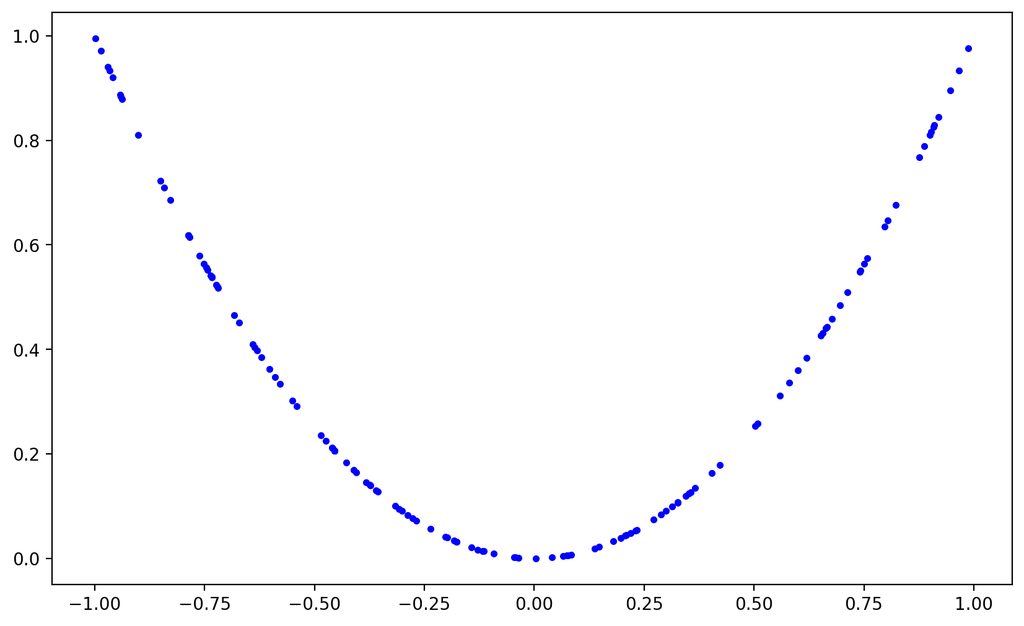

## Fitting

```python
m = model()
```

```python
m.loss_fn(params, x, y)
```

```
Array(5.9584, dtype=float32)
```

```python
params_fit = m.fit(params, x, y, n=1000)
m.loss_fn(params_fit, x, y)
```

```
Array(0.02912, dtype=float32)
```

```python
y_hat = m.forward(params_fit, x)
```

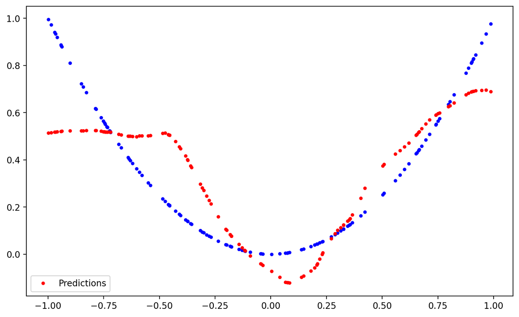

# What next?

## Additional Resources

There are a number of other libraries built on top of JAX that provide higher level interfaces for common tasks,

- Neural networks (torch-like interfaces)
  - [flax](https://flax.readthedocs.io/en/latest/) - Google brain
  - [haiku](https://dm-haiku.readthedocs.io/en/latest/) - DeepMind
  - [equinox](https://docs.kidger.site/equinox/)
- Bayesian models
  - [BlackJAX](https://blackjax-devs.github.io/blackjax/) - samplers for log-probability densities (optional backend for pymc)
- Other
  - [Optax](https://optax.readthedocs.io/en/latest/) - gradient processing and optimization library (DeepMind)
  - [Awesome-JAX](https://github.com/n2cholas/awesome-jax) - collection of JAX related links and resources